# tensortools: Tools for Tensor-Variate Distributions and Decompositions

Anupama Kannan

08/03/26

## Motivation

- Many datasets are naturally high-dimensional with structured covariance
  - RGB video - order 4 (x, y, color channel, time)
  - Medical imaging - order 4 (x, y, z, time)
  - Sensors over space and time
- Established software implementations and methods exist for vector- and matrix-variate data
- Analysts often matricize tensor data to use these methods

## Tensors

- Tensors - generalization of vectors and matrices (Kolda and Bader 2009)
- Order - number of indices needed to specify a value
  - Vector has order 1, matrix has order 2
- Mode - specific axis of tensor (rows = 1st mode, cols = 2nd mode)

## $\times_{n}$ Product

- Let $\tensor{A} \in \field{k}^{\color{red}{I_1} \times \color{red}{I_2} \times \dots \times \color{green}{I_n} \times \dots \times \color{red}{I_{O}}}$ and a matrix $\matrix{U} \in \field{k}^{\color{blue}{J} \times \color{green}{I_n}}$
- Then $\tensor{C} = \tensor{A} \times_{n} \mat{U}$ has entries

$$c_{\color{red}{i_1, \dots, i_{n-1},} \color{blue}{j} \color{red}{, i_{n+1}, \dots, i_O}} = \sum_{\color{green}{k=1}}^{\color{green}{I_n}} a_{\color{red}{i_1, \dots, i_{n-1}, \color{green}{k}, i_{n+1}, \dots, i_O}} u_{\color{blue}{j, \color{green}{k}}}$$

- The result has dimensions $I_1 \times \cdots \times I_{n-1} \times J \times I_{n+1} \times \cdots \times I_O$ and remains order $O$
- Acts along mode $n$ while leaving the other modes intact

## $\times_{n}$ Product

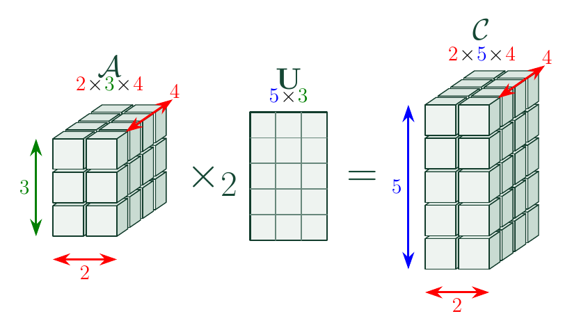

- Analogous to matrix multiplication
- The matrix acts along one mode of the tensor, forming weighted combinations along that mode

## Tensor Variate Normal (TVN)

| Object | Standard-normal | Transformation | Covariance structure |
| --- | --- | --- | --- |
| Scalar | $Z \in \mathbb{R}^{1}$ | $X=\mu+\sigma Z$ | $\sigma^2$ |
| Vector | $\ve{Z}\in\mathbb{R}^{p}$ | $\ve{X}=\boldsymbol{\mu}+\mat{A}\ve{Z}$ | $\mat{A}\mat{A}^{T}=\Sigma$ |
| Matrix | $\mat{Z}\in\mathbb{R}^{p\times q}$ | $\mat{X}=\mat{M} + \mat{A} \mat{Z} \mat{B}^{T}$ | $U=\mat{A}\mat{A}^{T},\;V=\mat{B} \mat{B}^{T}$ |
| Tensor | $\tensor{Z}\in\mathbb{R}^{I_1 \times \cdots \times I_D}$ | $\tensor{X}=\tensor{M} + \mathcal{Z} \times_{d=1}^{D} \mat{A}_{d}$ | $\Sigma_{d}=\mat{A}_{d}\mat{A}_{d}^{T}$ |

- Note that the matrix transform can be written as

$$\mat{X} = \mat{M} + \mat{Z} \times_{1} \mat{A} \times_{2} \mat{B}$$

- Start with IID standard normal draws in the structure, apply a linear transformation, add a mean (Ohlson et al. 2013)

## Tensor Variate Normal (TVN)

- Model assumption: separable covariance structure
  - Each mode $d$ has a covariance factor $\Sigma_d$
  - Together, the mode-specific factors define the full covariance:

  $$\text{vec}(\mathcal{X}) \sim N(\text{vec}(\tensor{M}), \Sigma_D\otimes\cdots\otimes\Sigma_1)$$
- Scaling identifiability issue: covariance structure is the same for different scalings of the covariance matrices
  - $\Sigma_{2} \otimes\Sigma_1 = a \Sigma_2 \otimes \frac{1}{a} \Sigma_{1}$
  - Only the full Kronecker product is uniquely determined (Manceur and Dutilleul 2013)

## TVN in tensortools

- `tensortools` supports r and d functions similar to base R
- `rtnorm()` requires arguments n, mu, sigmas
  - mu is the mean tensor. Its dimension is the same as the draws $\tensor{X}$
  - sigmas expects a list of covariance matrices. For mode $d$, $\Sigma_d \in \mathbb{R}^{I_d \times I_d}$

```r
(draws <- rtnorm(n = 100, mu = mu_true, sigmas = list(S1, S2, S3)))
# <tensor[100]>
# 100 draws of shape 2 × 3 × 4
#
# # Preview: 3 draws × 6 indexed entries
#         [1,1,1]  [2,1,1]  [1,2,1]  [2,2,1]  [1,3,1]  [2,3,1]
# draw 1 1.933572 3.758023 2.866924 5.553246 5.084797 7.007887
# draw 2 1.458150 2.540761 4.475832 3.368194 4.383154 5.348898
# draw 3 2.041212 4.245815 3.160716 5.029540 5.223698 7.717329
#
# # ... 97 more draws and 18 more entries per draw
```

## TVN in tensortools

- Density evaluation is also supported with `dtnorm()`
  - Requires arguments x, mu, sigmas

```r
dtnorm(draws[1], mu_true, sigmas = list(S1, S2, S3), log = TRUE)
# [1] -32.97781
```

## TVN in tensortools

- MLE estimation is supported with `tensor_mle()`
  - Requires arguments draws and model
  - Output is a list of the MLEs along with the log-likelihood, k, AIC, BIC

```r
tvn_mles <- tensor_mle(draws, model = "normal")

tvn_mles$sigmas[[1]]
#           [,1]      [,2]
# [1,] 1.0236879 0.4828938
# [2,] 0.4828938 0.9763121
S1
#      [,1] [,2]
# [1,]  1.0  0.5
# [2,]  0.5  1.0
```

## Tensor class

- Tensor class is internally an array
  - Stores $n$ IID observations, operations apply to each one

```r
print(draws[1:2], entries = 3)
# <tensor[2]>
# 2 draws of shape 2 × 3 × 4
#
# # Preview: 2 draws × 3 indexed entries
#         [1,1,1]  [2,1,1]  [1,2,1]
# draw 1 1.933572 3.758023 2.866924
# draw 2 1.458150 2.540761 4.475832
#
# # ... 21 more entries per draw
```

## Tensor class

```r
centered_draws <- draws - mu_true

print(centered_draws[1:2], entries = 3)
# <tensor[2]>
# 2 draws of shape 2 × 3 × 4
#
# # Preview: 2 draws × 3 indexed entries
#          [1,1,1]  [2,1,1]    [1,2,1]
# draw 1 0.9335718 1.758023 -0.1330757
# draw 2 0.4581498 0.540761  1.4758318
#
# # ... 21 more entries per draw

print(n_prod(centered_draws[1:2], 1, S1), entries = 3)
# <tensor[2]>
# 2 draws of shape 2 × 3 × 4
#
# # Preview: 2 draws × 3 indexed entries
#          [1,1,1]   [2,1,1]   [1,2,1]
# draw 1 1.8125833 2.2248089 0.6435474
# draw 2 0.7285303 0.7698359 1.1599286
#
# # ... 21 more entries per draw
```

## Application: GRABMyo

- GRABMyo (Gesture Recognition and Biometrics Electromyogram) data from **43 participants** treated as IID observations (Jiang et al. 2024; Pradhan et al. 2022)
- Each participant performed **16 hand gestures** in 7 repeated trials
- There were **28 active EMG channels**
- Collapse each 5-second recording at 2,048 Hz into **16 time bins**
- Average the seven trials for each participant and gesture after time binning
- Each observation is a $16\;\text{gestures}\times 28\;\text{channels}\times 16\;\text{time bins}$ tensor

## GRABMyo: electrode layout and gesture set

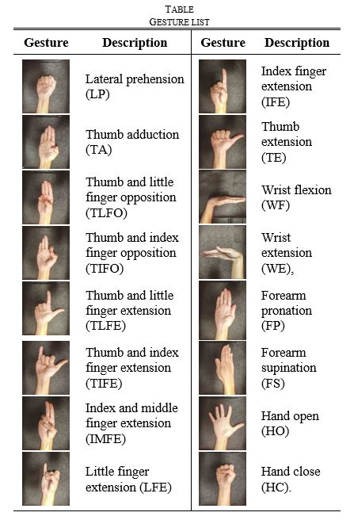

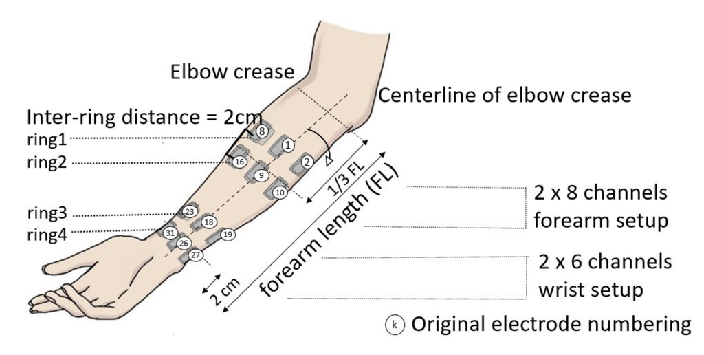

## GRABMyo Values

[figure not shown]

## GRABMyo Model Output

Tensor-normal and matrix-normal fits to the GRABMyo data.

| model | dimensions | loglik | k | BIC | AIC | secs |
| --- | --- | --- | --- | --- | --- | --- |
| tensor | 16 x 28 x 16 | 637062.9 | 7844 | -1244623 | -1258438 | 1.5 |
| mat2 | 28 x 256 | 676266.7 | 40469 | -1200321 | -1271595 | 3.2 |
| mat3 | 16 x 448 | 737814.6 | 107879 | -1069875 | -1259871 | 15.0 |
| mat1 | 16 x 448 | 722443.7 | 107879 | -1039133 | -1229129 | 6.7 |

- Matrix-normal models have larger likelihoods because they are less constrained
- BIC favors the tensor model: reduction in complexity is worth the loss in likelihood

## Skewed Tensor Distributions

$$\tensor{X} = \tensor{M} + W \tensor{A} + \sqrt{W} \tensor{V}, \qquad
\tensor{V}\sim\text{TVN}\!\left(\tensor{0},\{\Sigma_d\}_{d=1}^{D}\right)$$
(Barndorff-Nielsen et al. 1982)

| Distribution | Distribution of W | Param | Support |
| --- | --- | --- | --- |
| Skewed-t | Inverse-gamma(ν/2, ν/2) | ν | ν > 0 |
| Generalized hyperbolic | Gen Inv Gauss(ω, 1, λ) | λ, ω | ω > 0; λ ∈ ℝ |
| Variance-gamma | Gamma(γ, γ) | γ | γ > 0 |
| Normal inverse Gaussian | Inv Gauss(1, κ) | κ | κ > 0 |

## Skewed Tensor Distributions in tensortools

- `tensortools` supports r, d, and MLE functions for all of these distributions
- MLE estimation is done using the EM algorithm

```r
(skewt_draws <- rtskewt(n = 1e3, mu = mu_true, sigmas = sigmas_true,
                       skew = skew_true, nu = 20))
# <tensor[1,000]>
# 1,000 draws of shape 2 × 3 × 4
#
# # Preview: 3 draws × 6 indexed entries
#         [1,1,1]  [2,1,1]  [1,2,1]  [2,2,1]  [1,3,1]   [2,3,1]
# draw 1 3.643947 4.425661 5.973282 9.331688 8.096839 10.628325
# draw 2 2.994855 3.973106 3.989750 5.064052 7.983755  9.506291
# draw 3 2.052635 2.889480 4.742515 6.128241 7.228344 10.330539
#
# # ... 997 more draws and 18 more entries per draw

mle_skewt <- tensor_mle(skewt_draws, model = "skewt")
```

## GRABMyo Data with Skew

Tensor distribution fits to the 43 processed GRABMyo participant tensors.

| model | loglik | k | AIC | BIC | secs |
| --- | --- | --- | --- | --- | --- |
| Skew-t | 651376.6 | 15013 | -1272727 | -1246286 | 6.4 |
| Gen Hyper | 651375.5 | 15014 | -1272723 | -1246280 | 6.4 |
| Norm Inv Gauss | 651362.5 | 15013 | -1272699 | -1246258 | 6.9 |
| Var Gamma | 651260.9 | 15013 | -1272496 | -1246055 | 5.3 |
| Normal | 637062.9 | 7844 | -1258438 | -1244623 | 1.5 |

- Skew-$t$ has lowest AIC and BIC even with an additional skew tensor
- AIC and BIC favor skew-$t$ over normal, consistent with skewness

## Interpretation

[figure not shown]

- Cross-gesture correlations are generally weak while time-bin correlations are strong
- EMG has two blocks of stronger within-group correlation: 16 forearm channels and 12 wrist channels

## Thank You!

Barndorff-Nielsen, O., J. Kent, and M. Sørensen. 1982. “Normal Variance-Mean Mixtures and z Distributions.” *International Statistical Review* 50 (2): 145–59.

Jiang, Ning, Ashirbad Pradhan, and Jiayuan He. 2024. “Gesture Recognition and Biometrics ElectroMyogram (GRABMyo).” *PhysioNet*, ahead of print, June. https://doi.org/10.13026/89dm-f662.

Kolda, Tamara G., and Brett W. Bader. 2009. “Tensor Decompositions and Applications.” *SIAM Review* 51 (3): 455–500. https://doi.org/10.1137/07070111X.

Manceur, Ameur M., and Pierre Dutilleul. 2013. “Maximum Likelihood Estimation for the Tensor Normal Distribution: Algorithm, Minimum Sample Size, and Empirical Bias and Dispersion.” *Journal of Computational and Applied Mathematics* 239: 37–49. https://doi.org/10.1016/j.cam.2012.09.017.

Ohlson, Martin, M. Rauf Ahmad, and Dietrich von Rosen. 2013. “The Multilinear Normal Distribution: Introduction and Some Basic Properties.” *Journal of Multivariate Analysis* 113: 37–47. https://doi.org/10.1016/j.jmva.2011.05.015.

Pradhan, Ashirbad, Jiayuan He, and Ning Jiang. 2022. “Multi-Day Dataset of Forearm and Wrist Electromyogram for Hand Gesture Recognition and Biometrics.” *Scientific Data* 9: 733. https://doi.org/10.1038/s41597-022-01836-y.

- Thank you to my advisors Dr. David Kahle and Dr. Michael Gallaugher
- Any questions?

[figure not shown]

## W Latent Distributions

$W \sim \text{Inverse-Gamma}(\nu/2, \nu/2)$

$$f(w|\nu) = \frac{(\nu/2)^{\nu/2}}{\Gamma(\nu/2)} w^{-(\nu/2+1)} \exp\left[-\frac{\nu/2}{w}\right]$$

- $W \sim \text{Gamma}(\gamma, \gamma)$

$$f(w|\gamma) = \frac{1}{\gamma^{\gamma}\Gamma(\gamma)} w^{\gamma - 1} e^{-w/\gamma}$$

- $W \sim \text{Inverse-Gaussian}(1, \kappa)$

$$f(w|\kappa) = \frac{1}{\sqrt{2\pi}} w^{-\frac{3}{2}} \exp\left\{-\frac{1}{2}\left(\frac{1}{w} + \kappa^2 w\right)\right\}$$

- $Y \sim \text{Generalized Inverse Gaussian}(\omega, 1, \lambda)$

$$f(w|\omega, b, \lambda) = \frac{\left(\omega\right)^{\frac{\lambda}{2}} y^{\lambda -1}}{2 K_{\lambda}(\sqrt{\omega})} \exp\left\{-\frac{x}{2} \left(w + \frac{1}{w}\right)\right\}$$